# Sesion 11 - Contruccion de Modelos / Agregacion de Riesgos

Juan Carlos Martínez-Ovando

Otoño 2019

# 1 Objetivos

- Implementaremos los tres criterios de comparacion y seleccion de modelos.
- Estudiaremos las alternativas viables para calcular la distribucion del monto agregado de siniestros.
- Ilustraremos esta sesion con los datos de `AllState`.

# 2 Preliminares

En el archivo `markdown` ejecutamos las rutinas previas se la `sesion 10`.

## 2.1 Distribucion Pareto

## 2.2 Distribucion Lognormal

La estimacion de la distirbucion log-normal se obtiene de la siguiente forma:

```r
library("MASS")
par.lognorm <- fitdistr(severidades.train,"lognormal")
par.lognorm
```

```
##     meanlog       sdlog
##   3.60458741   1.83813098
##  (0.03355393) (0.02372621)
```

La densidad de la distribucion estimada es:

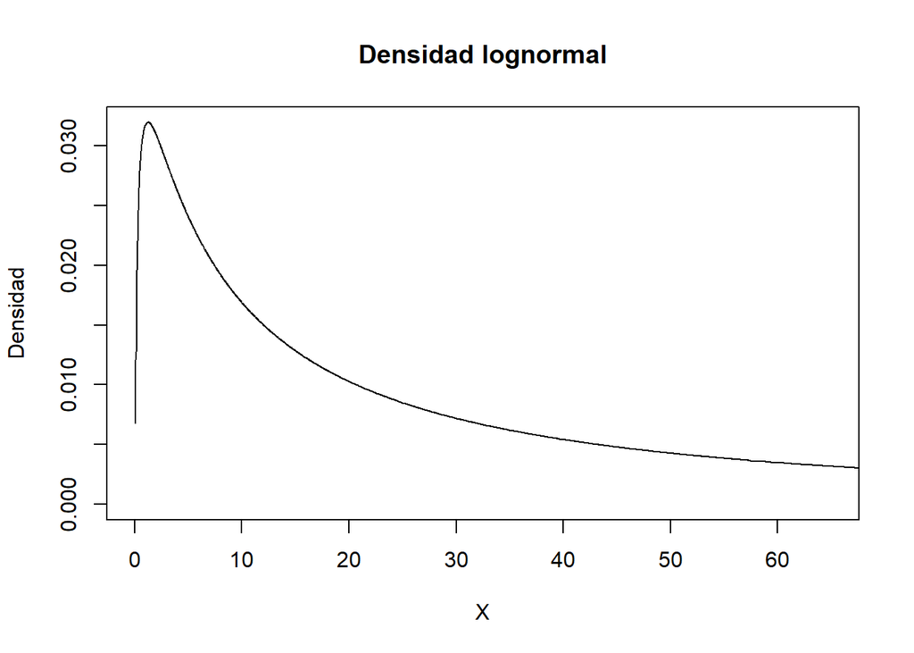

```r
severidades.train.unique <- sort(unique(severidades.train))
d.lognorm <- dlnorm(severidades.train.unique,
                    par.lognorm$estimate['meanlog'],
                    par.lognorm$estimate['sdlog'])

plot(severidades.train.unique, d.lognorm, type="l",
     ylab="Densidad",
     xlab="X",
     xlim=c(0,65))
title(main = "Densidad lognormal")
```

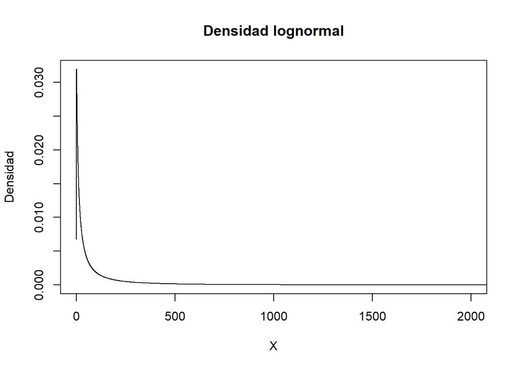

```r
plot(severidades.train.unique, d.lognorm, type="l",
     ylab="Densidad",
     xlab="X",
     xlim=c(0,2000))
title(main = "Densidad lognormal")
```

## 2.3 Distribucion gamma generalizada

## 2.4 Distribucion beta generalizada del segundo tipo

La estimacion de los parametros de la distribucion beta generalizada del segundo tipo se obtene de la siguiente forma:

```r
library("GB2")
par.gb2 <- mlfit.gb2(severidades.train)
```

```
## [1] Warning: negative parameter
```

```r
par.gb2
```

```
## [[1]]
##       type median mean  ARPR    RMPG    QSR GINI likelihood    a     b
## 1 Emp. est     36  174 39.95   65.57 197.95 0.77         NA   NA    NA
## 2  ML full     36  238 38.88   63.34 278.35 0.84      5.634 0.31 18.90
## 3  ML prof     37  199 60.95 -326.24   0.00   NA      5.632 0.00 31.82
##              p            q
## 1           NA           NA
## 2 7.440000e+00 6.160000e+00
## 3 6.867282e+10 6.867285e+10
##
## [[2]]
## [[2]]$par
## [1]  0.3061713 18.9009652  7.4430120  6.1609407
##
## [[2]]$value
## [1] 5.634306
##
## [[2]]$counts
## function gradient
##      105       85
##
## [[2]]$convergence
## [1] 0
##
## [[2]]$message
## NULL
##
##
## [[3]]
## [[3]]$par
## [1] -2.935932e-06  3.182347e+01
##
## [[3]]$value
## [1] 5.632233
##
## [[3]]$counts
## function gradient
##      103       14
##
## [[3]]$convergence
## [1] 0
##
## [[3]]$message
## NULL
```

## 2.5 Distribucion Pareto generalizada

# 3 Comparacion de modelos

En esta secion implementaremos el procedimiento de `comparacion` y `seleccion` del modelo para *severidades individuales*. Realizaremos la ilustracion con tres enfoques:

1. Bondad de ajuste
2. Cociente de verosimilitud
3. Cociente de veroimilitud extendida

## 3.1 Bondad de ajuste

Este enfoque basicamente consiste en contrastar los **cinco modelos parametricos** en terminos de sus `cercania/semejanza` con la **EDF**.

Los criterios difieren, escencialmente, en la `metrica` empleada para calcular la `cercania/semejanza` entre distribuciones.

Definimos, de manera general, a $F_{edf}(X)$ como la funcion de distirbucion empirica y $F_j(x|\hat{\theta}_j)$ como la distirbucion parametrica estimada (puntualmente) del tipo de modelo $j$.

### 3.1.1 Kolmogorov-Smirnov

El estadistico para medir la `cercania/semejanza` entre distribuciones $edf$ y $j$ bajo Kolmogorov-Smirnov (KS) es
$$T_{KS}(j)=\max_{x}|F_{edf}(x)-F_j(x|\hat{\theta}_j)|,$$
para $j=1,\ldots,J$.

**Nota.** La $edf$ es discreta, por lo que el calculo de $T_{KS}(j)$ debe realizarse en dos puntos para cada valor de $x$:

- $F_{edf}(x-)$ que es el limite por la izquierda antes de $x$
- $F_{edf}(x)$ que es el limite por la derecha antes de $x$.

Los valores criticos tradicionalmente empleados para esta estadistica son:

1. $T_\alpha=\frac{1.22}{\sqrt{n}}$ para $\alpha=0.10$ nivel de significacia,
2. $T_\alpha=\frac{1.36}{\sqrt{n}}$ para $\alpha=0.05$ nivel de significacia,
3. $T_\alpha=\frac{1.63}{\sqrt{n}}$ para $\alpha=0.01$ nivel de significacia,

donde $n$ es el tamnio de la muestra.

### 3.1.2 Anderson-Darling

En la opcion anderson-Darling (AD), la metrica para medir la `cercania/semejanza` entre distribuciones $edf$ y $j$ es definida como
$$T_{AD}(j)=-nF_j(x^*_U|\hat{\theta}_j)
+n\sum_{u=1}^{U-1} [1-F_{edf}(x^*_u)]^2 \left\{\text{log}[1-F_j(x^*_u|\hat{\theta}_j)]-\text{log}[1-F_j(x^*_{u+1}|\hat{\theta}_j)]\right\}
+ n \sum_{u=2}^{U} F_{edf}(x_u^*)^2 \left[\text{log}F_j(x^*_{u+1}|\hat{\theta}_j)-\text{log}F_j(x^*_u|\hat{\theta}_j)\right],$$
donde $\{x_u^*\}_{u=1}^{U}$ corresponden a los $U$ datos unicos disponibles.

**Nota:** En este calculo, se hace explicito la consideracion de comparacion entre `limites por la derecha` y `limites por la izquierda` relacionados con $F_{edf}(\cdot)$.

Los valores critios, para esta prueba, son tipicamente:

1. $T_a=1.933$ para $a=0.10$,
2. $T_a=2.492$ para $a=0.05$,
3. $T_a=3.857$ para $a=0.01$.

## 3.2 Verosimilitud

El cociente de verosimilitudes, consiste basicamente en calcular la `verosimilitud del modelo especifico` para los datos. Esta verosimilitud se calcula en dos pasos.

1. Calcula el `estimador puntual` (via `maxima verosimilitud`) de `\theta_j`, para `j=1,\ldots,J`, con base en los datos $\{x_1,\ldots,x_n\}$.

Recuerden, de los datos extraemos los datos unicos $\{x_1^*,\ldots,x_U^*\}$ (las frecuencias de los datos unicos no son requeridas en este contexto).

2. Con el `estimador puntual del modelo especifico`, $F_{j}(x|\hat{\theta}_j)$, recuperamos su correspondiente densidad y calculamos la `verosimilitud del modelo` $j$ de la siguiente forma:
   $$lik(j)=\prod_{u=1}^{U}f_j(x_u^*|\hat{\theta}_{j}),$$
   para $j=1,\ldots,J$.

Por cuestiones numericas, es conveniente trabajar con la `log-verosimilitud`,
$$loglik(j)=\sum_{u=1}^{U} \text{log}f_j(x_u^*|\hat{\theta}_{j}).$$

**Noten** que la verosimilitud del modelo se calcula sobre un segmento de los mismos datos con los que se estimo el modelo, `datos de entrenamiento`.

## 3.3 Verosimilitud predictiva

Una variante del `procedimiento basado en verosimilitud` para evaluar la capacidad predictiva del modelo consiste en realizar la siguiente modificacion:
$$ploglik(j)=\sum_{u=1}^{U} \text{log}f_j(x_u^t|\hat{\theta}_{j}),$$
donde $\{x_u^t\}_{u=1}^{U}$ corresponden a los $U$ valores unicos de los `datos de prueba/test`.

**Noten** que la evaluacion de las densidades en los datos de prueba brinda una cuantificacion de que tanta masa de probabilidad el modelo predictivo asigna a los valores que realmente ocurrieron (pero que no fueron empleados en el proceso de estimacion).

# 4 Ejercicios

- Realizar el `Proceso de aprendizaje I` completando la estimacion de las distribuciones faltantes.
- Realizar el `Proceso de aprendizaje II`

# 5 Lectura complementaria

- Kleiber & Kotz, *Statistical Size Distribution in Economics and Actuarial Science*.
  - Capitulo 3 (distribucion Pareto).
  - Capitulo 4 (distribucion lognormal).
  - Capitulo 5 (distribucion gamma generalizada).
  - Capitulo 6 (distribucion beta generalizada).
- Embrechts et al. *Modelling Extremal Events for Insurance and Finance*.
  - Capitulos 3 y 6 (distribucion Pareto generalizada).